# Predicting Pet Adoption Speed With XGBoost in Python

## Introduction

This is an analysis that I did for the Kaggle 'PetFinder.my Adoption Prediction' competition (https://www.kaggle.com/c/petfinder-adoption-prediction/data). The goal of the competition is to predict how quickly a pet will be adopted based on characteristics of their online profile. You can toggle the code with the show/hide code button on the top left of the page.

The target variable is 'Adoption Speed' which is an ordinal integer variable ranging from 0 to 4. If 0, the pet was adopted on the same day it was listed, and if 4, the pet had not yet been adopted after 100 days. The accuracy metric for the competetion is the quadratic weighted kappa, which measures the agreement between Adoption Speed and model predictions. This metric varies from 0 (random agreement) to 1 (complete agreement), and penalizes predictions that are further away from the target.

The competition data includes tabular, text, and image data. The tabular data includes information such as the pet's age, gender and size. The text data is the discription of the pet, and the image data are the images of the pet on the profile. The text and image data have been run through Google's Natural Language, and Vision APIs and the results can be added to the dataset for inclusion as model predictors.

## Exploratory Data Analysis and Feature Engineering

```python
import numpy as np
import pandas as pd
import matplotlib.pyplot as plt
import seaborn as sns
import json
from sklearn.preprocessing import OneHotEncoder
from sklearn.model_selection import GridSearchCV
from sklearn.model_selection import train_test_split
from sklearn.preprocessing import StandardScaler
import xgboost as xgb
from sklearn.metrics import confusion_matrix
from functools import partial
import scipy as sp
```

First import the tabular data and look at the dimensions:

```python
train = pd.read_csv('/Users/Joshua/Documents/Anaconda/PetFinderData/train.csv')
test = pd.read_csv('/Users/Joshua/Documents/Anaconda/PetFinderData/test.csv')
print(train.shape)
print(test.shape)
full_data = [train, test]
```

```
(14993, 24)
(3948, 23)
```

Look at the variable names, data type, and whether there are any missing values.

```python
train.info()
```

```
<class 'pandas.core.frame.DataFrame'>
RangeIndex: 14993 entries, 0 to 14992
Data columns (total 24 columns):
Type             14993 non-null int64
Name             13736 non-null object
Age              14993 non-null int64
Breed1           14993 non-null int64
Breed2           14993 non-null int64
Gender           14993 non-null int64
Color1           14993 non-null int64
Color2           14993 non-null int64
Color3           14993 non-null int64
MaturitySize     14993 non-null int64
FurLength        14993 non-null int64
Vaccinated       14993 non-null int64
Dewormed         14993 non-null int64
Sterilized       14993 non-null int64
Health           14993 non-null int64
Quantity         14993 non-null int64
Fee              14993 non-null int64
State            14993 non-null int64
RescuerID        14993 non-null object
VideoAmt         14993 non-null int64
Description      14981 non-null object
PetID            14993 non-null object
PhotoAmt         14993 non-null float64
AdoptionSpeed    14993 non-null int64
dtypes: float64(1), int64(19), object(4)
memory usage: 2.7+ MB
```

Name has some missing values.

I now examine the variables one at a time.

### AdoptionSpeed

The target variable: the length of time before a pet was adopted:

0 = The pet was adopted on the same day as it was listed

1 = The pet was adopted in first week

2 = The pet was adopted between 8 and 30 days (1st month)

3 = The pet was adopted between 31 and 90 days (2nd & 3rd month)

4 = No adoption after 100 days of being listed

Alghough it is ordinal, I treat Adoption Speed as a continuous variable in the exploratory data analysis, since I am going to model it as continuous and then choose the cut points afterwards due to the accuracy metric being used in this competition (quadratic weighted kappa).

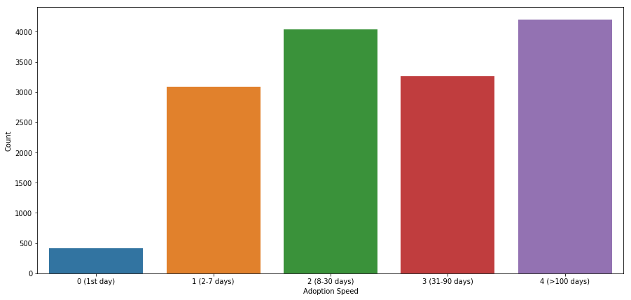

```python
plt.figure(figsize=(15, 7))
ax = sns.countplot(x='AdoptionSpeed', data=train)
plt.xticks([0, 1, 2, 3, 4], ['0 (1st day)', '1 (2-7 days)', '2 (8-30 days)', '3 (31-90 days)', '4 (>100 days)'])
plt.xlabel('Adoption Speed')
plt.ylabel('Count')
plt.show()
```

### Type

Type of pet: 1 = dog, 2 = cat

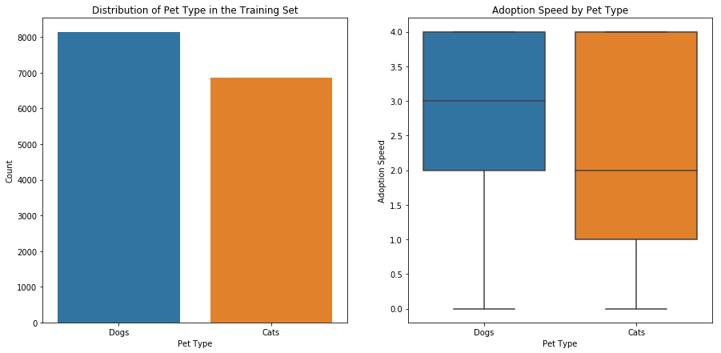

```python
plt.figure(figsize=(15, 7))
plt.subplot(1, 2, 1)
ax = sns.countplot(x='Type', data=train)
plt.title('Distribution of Pet Type in the Training Set')
plt.xlabel('Pet Type')
plt.xticks([0, 1], ['Dogs', 'Cats'])
plt.ylabel('Count')
plt.subplot(1, 2, 2)
ax = sns.boxplot(x='Type', y='AdoptionSpeed', data=train)
plt.title('Adoption Speed by Pet Type')
plt.xlabel('Pet Type')
plt.xticks([0, 1], ['Dogs', 'Cats'])
plt.ylabel('Adoption Speed')
plt.show()
```

There are more dogs than cats, and on average, cats are more likely to be adopted sooner.

### Name

Name of the pet

I recoded this variable into the value counts.

```python
train.Name.head()
```

```
0         Nibble
1    No Name Yet
2         Brisco
3           Miko
4         Hunter
Name: Name, dtype: object
```

```python
train.Name.value_counts().head(15)
```

```
Baby       66
Lucky      64
Brownie    54
No Name    54
Mimi       52
Blackie    49
Puppy      45
Max        39
Kitty      39
Kittens    39
Oreo       36
Coco       35
Tiger      34
Angel      33
Milo       32
Name: Name, dtype: int64
```

```python
train['Name'] = train['Name'].replace(['No Name', 'No Name Yet'], np.NaN)
test['Name'] = test['Name'].replace(['No Name'], np.NaN)
```

```python
name_dict = train.Name.value_counts().to_dict()
train.Name = train.Name.map(name_dict)

name_dict = test.Name.value_counts().to_dict()
test.Name = test.Name.map(name_dict)

for dataset in full_data:
    dataset['Name'] = dataset['Name'].fillna(0)
```

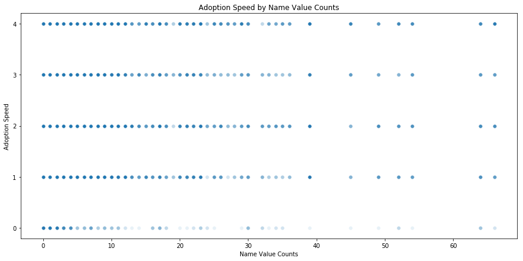

```python
plt.figure(figsize=(15, 7))
ax = sns.scatterplot(x='Name', y='AdoptionSpeed', data=train, alpha=0.1)
plt.title('Adoption Speed by Name Value Counts')
plt.ylabel('Adoption Speed')
plt.xlabel('Name Value Counts')
plt.yticks([0, 1, 2, 3, 4])
plt.show()
```

Not having a name may affect adoption speed.

```python
train['Name'] = train['Name'].fillna('No_name')
test['Name'] = test['Name'].fillna('No_name')
train['NoName'] = train.apply(lambda x: 1 if x['Name']==0 else 0, axis=1)
test['NoName'] = test.apply(lambda x: 1 if x['Name']==0 else 0, axis=1)
```

```python
pd.crosstab(train['NoName'], train['AdoptionSpeed'], normalize='index')
```

| AdoptionSpeed NoName | 0 | 1 | 2 | 3 | 4 |
| --- | --- | --- | --- | --- | --- |
| 0 | 0.027818 | 0.204978 | 0.271230 | 0.222035 | 0.273939 |
| 1 | 0.022506 | 0.217554 | 0.249062 | 0.169542 | 0.341335 |

Unnamed animals are less likely to be adopted.

### Age

Age in months

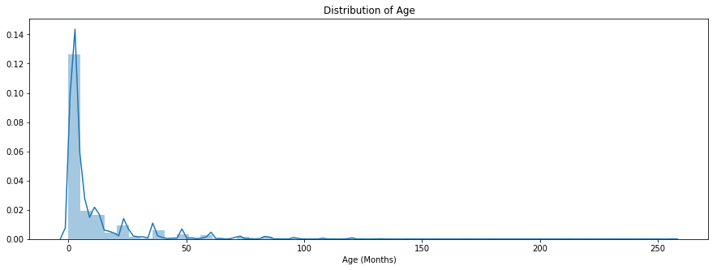

```python
plt.figure(figsize=(15, 5))
ax = sns.distplot(train['Age'])
plt.title('Distribution of Age')
plt.xlabel('Age (Months)')
plt.show()
```

```python
train.Age.describe()
```

```
count    14993.000000
mean        10.452078
std         18.155790
min          0.000000
25%          2.000000
50%          3.000000
75%         12.000000
max        255.000000
Name: Age, dtype: float64
```

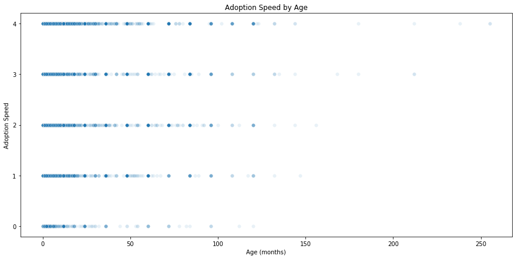

```python
plt.figure(figsize=(15, 7))
ax = sns.scatterplot(x='Age', y='AdoptionSpeed', data=train, alpha=0.1)
plt.title('Adoption Speed by Age')
plt.xlabel('Age (months)')
plt.ylabel('Adoption Speed')
plt.yticks([0, 1, 2, 3, 4])
plt.show()
# there are some outliers >200 is very old, but I will leave them since they are all in group 3 or 4 which makes sense
```

### Breed (Breed1 & Breed2)

Breed1 is the primary breed, and Breed2 is the secondary breed for mixed breed animals. Since purebred is reported as an important variable in the literature I will create a 'PureBred' feature, and label encode Breed1 and Breed2. The labels are in the labels csv (307 = mixed breed).

```python
train.Breed1.value_counts().head()
```

```
307    5927
266    3634
265    1258
299     342
264     296
Name: Breed1, dtype: int64
```

```python
# Import the breed labels
breed_labels = pd.read_csv('/Users/Joshua/Documents/Anaconda/PetFinderData/breed_labels.csv')
# make BreedID the index and drop 'Type' (dog or cat)
breed_labels = breed_labels.set_index('BreedID').drop('Type', axis=1).to_dict()
```

Create 'PureBred' variable.

```python
train['PureBred'] = train.apply(lambda x: 1 if x['Breed2']==0 and x['Breed1']!=307 else 0, axis=1)
test['PureBred'] = test.apply(lambda x: 1 if x['Breed2']==0 and x['Breed1']!=307 else 0, axis=1)
```

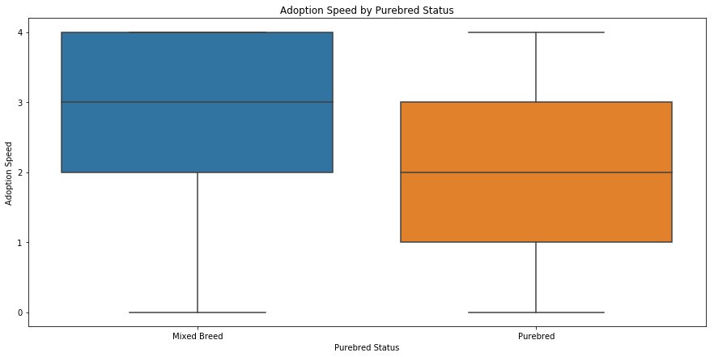

```python
plt.figure(figsize=(15, 7))
ax = sns.boxplot(x='PureBred', y='AdoptionSpeed', data=train)
plt.title('Adoption Speed by Purebred Status')
plt.xlabel('Purebred Status')
plt.xticks([0, 1], ['Mixed Breed', 'Purebred'])
plt.ylabel('Adoption Speed')
plt.yticks([0, 1, 2, 3, 4])
plt.show()
```

Consistent with the literature, purebred animals are adopted quicker.

```python
train['Breed1'] = pd.factorize(train['Breed1'])[0]
test['Breed1'] = pd.factorize(test['Breed1'])[0]
```

### Gender

Gender of pet (1 = Male, 2 = Female, 3 = Mixed, if profile represents group of pets)

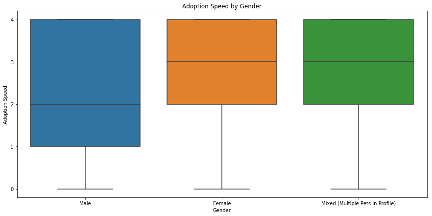

```python
plt.figure(figsize=(15, 7))
ax = sns.boxplot(x='Gender', y='AdoptionSpeed', data=train)
plt.xticks([0, 1, 2], ['Male', 'Female', 'Mixed (Multiple Pets in Profile)'])
plt.ylabel('Adoption Speed')
plt.title('Adoption Speed by Gender')
plt.yticks([0, 1, 2, 3, 4])
plt.show()
```

Average adoption speed for males is lower.

### Colour

Colour 1, 2 and 3 of pet

```python
colour_labels = pd.read_csv('/Users/Joshua/Documents/Anaconda/PetFinderData/color_labels.csv')
colour_labels
# ColorID = 0 is missing
```

|  | ColorID | ColorName |
| --- | --- | --- |
| 0 | 1 | Black |
| 1 | 2 | Brown |
| 2 | 3 | Golden |
| 3 | 4 | Yellow |
| 4 | 5 | Cream |
| 5 | 6 | Gray |
| 6 | 7 | White |

```python
train.Color1.value_counts()
```

```
1    7427
2    3750
3     947
5     884
6     684
7     667
4     634
Name: Color1, dtype: int64
```

Black and brown are most common.

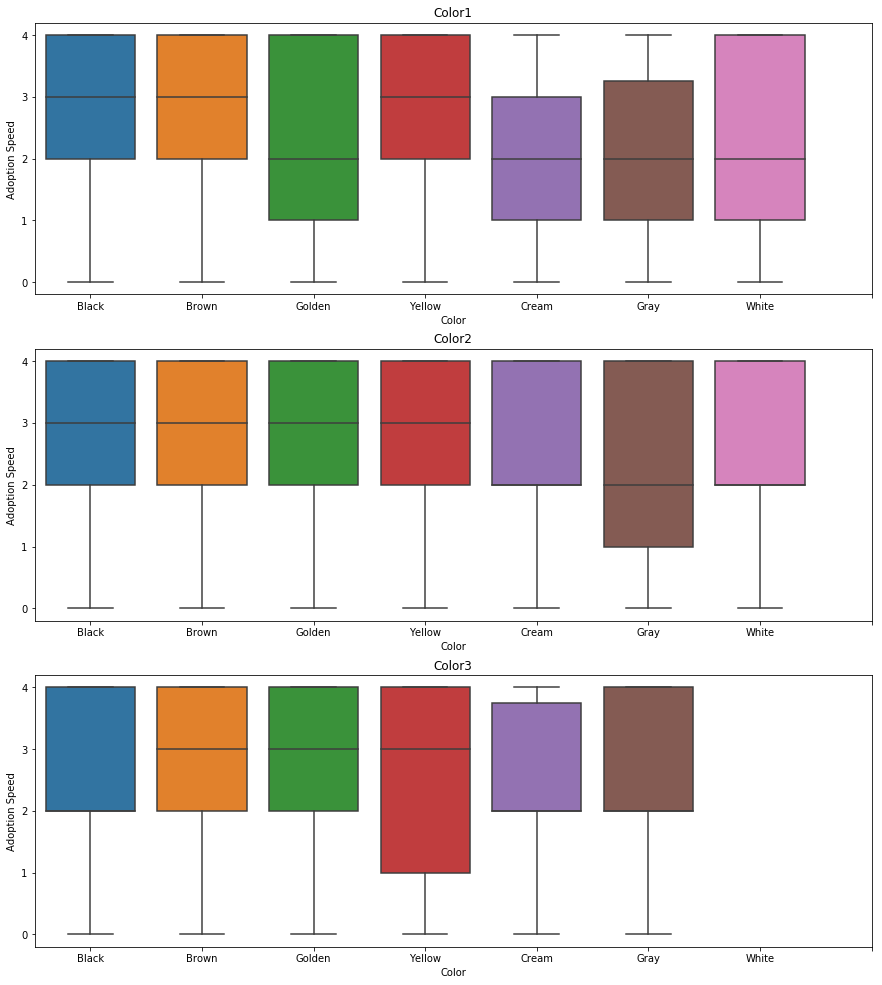

```python
plt.figure(figsize=(15, 17))
plt.subplot(3, 1, 1)
ax = sns.boxplot(x='Color1', y='AdoptionSpeed', data=train)
plt.title('Color1')
plt.xlabel('Color')
plt.ylabel('Adoption Speed')
plt.yticks([0, 1, 2, 3, 4])
plt.xticks([0, 1, 2, 3, 4, 5, 6, 7], ['Black', 'Brown', 'Golden', 'Yellow', 'Cream', 'Gray', 'White'])
plt.subplot(3, 1, 2)
ax = sns.boxplot(x='Color2', y='AdoptionSpeed', data=train)
plt.title('Color2')
plt.xlabel('Color')
plt.ylabel('Adoption Speed')
plt.yticks([0, 1, 2, 3, 4])
plt.xticks([0, 1, 2, 3, 4, 5, 6, 7], ['Black', 'Brown', 'Golden', 'Yellow', 'Cream', 'Gray', 'White'])
plt.subplot(3, 1, 3)
ax = sns.boxplot(x='Color3', y='AdoptionSpeed', data=train)
plt.xlabel('Color')
plt.ylabel('Adoption Speed')
plt.yticks([0, 1, 2, 3, 4])
plt.xticks([0, 1, 2, 3, 4, 5, 6, 7], ['Black', 'Brown', 'Golden', 'Yellow', 'Cream', 'Gray', 'White'])
plt.title('Color3')
plt.show()
```

For color1 average adoption speed for most of the lighter colours is lower (golden, cream, gray, white). But there does not seem to be much signal in color2 or color3 - I will not include these in the model.

### Maturity Size

Size at maturity (1 = Small, 2 = Medium, 3 = Large, 4 = Extra Large, 0 = Not Specified)

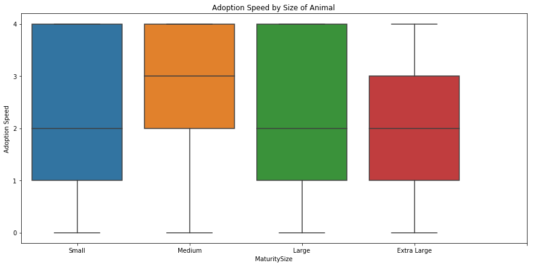

```python
plt.figure(figsize=(15, 7))
ax = sns.boxplot(x='MaturitySize', y='AdoptionSpeed', data=train)
plt.xticks([0, 1, 2, 3, 4], ['Small', 'Medium', 'Large', 'Extra Large'])
plt.title('Adoption Speed by Size of Animal')
plt.ylabel('Adoption Speed')
plt.yticks([0, 1, 2, 3, 4])
plt.show()
```

Small and large dogs are adopted more quickly compared to medium.

### Fur Length

Fur length (1 = Short, 2 = Medium, 3 = Long, 0 = Not Specified)

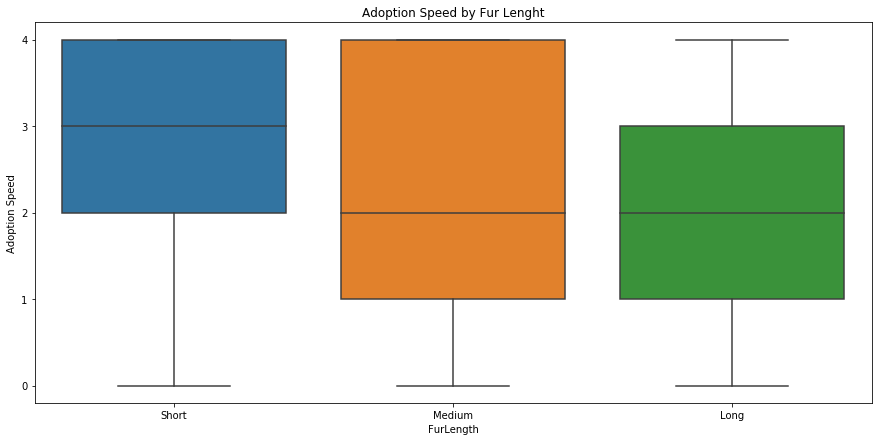

```python
plt.figure(figsize=(15, 7))
ax = sns.boxplot(x='FurLength', y='AdoptionSpeed', data=train)
plt.xticks([0, 1, 2], ['Short', 'Medium', 'Long'])
plt.title('Adoption Speed by Fur Lenght')
plt.ylabel('Adoption Speed')
plt.yticks([0, 1, 2, 3, 4])
plt.show()
```

Medium and long haired animals are adopted more quickly.

### Vaccinated

Pet has been vaccinated (1 = Yes, 2 = No, 3 = Not Sure)

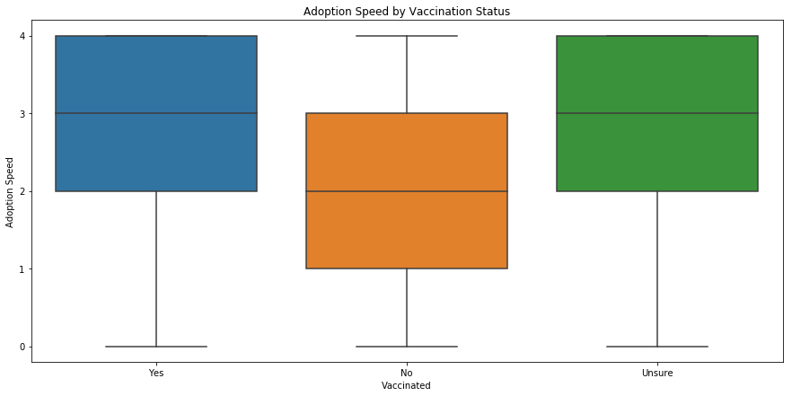

```python
plt.figure(figsize=(15, 7))
ax = sns.boxplot(x='Vaccinated', y='AdoptionSpeed', data=train)
plt.title('Adoption Speed by Vaccination Status')
plt.xticks([0, 1, 2], ['Yes', 'No', 'Unsure'])
plt.ylabel('Adoption Speed')
plt.yticks([0, 1, 2, 3, 4])
plt.show()
```

This is surprising, age may be confounding - unvaccinated older animals may be less likely to be adopted.

### Dewormed

Pet has been dewormed (1 = Yes, 2 = No, 3 = Not Sure)

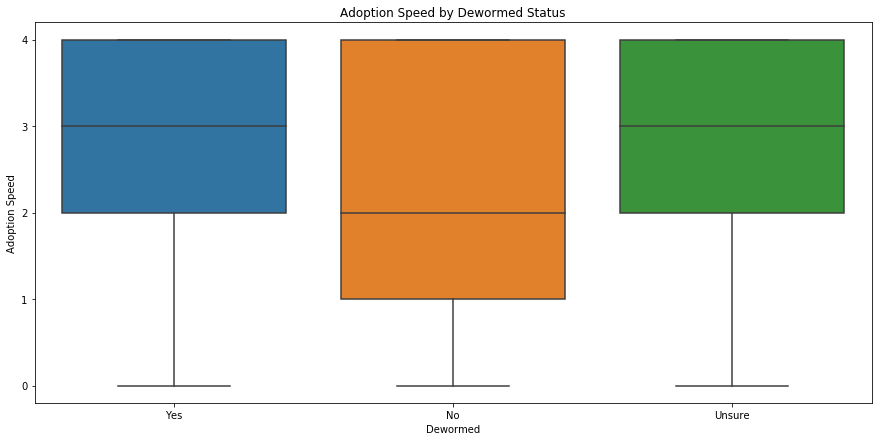

```python
plt.figure(figsize=(15, 7))
ax = sns.boxplot(x='Dewormed', y='AdoptionSpeed', data=train)
plt.title('Adoption Speed by Dewormed Status')
plt.xticks([0, 1, 2], ['Yes', 'No', 'Unsure'])
plt.ylabel('Adoption Speed')
plt.yticks([0, 1, 2, 3, 4])
plt.show()
```

### Sterilized

Pet has been spayed / neutered (1 = Yes, 2 = No, 3 = Not Sure)

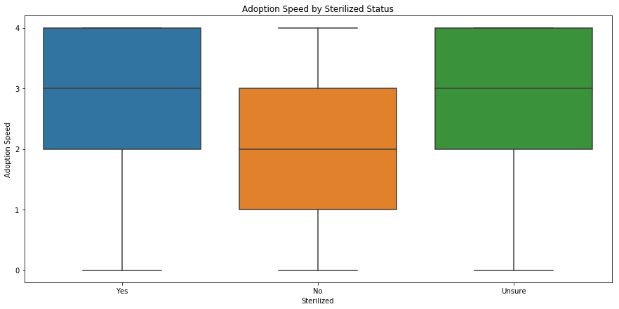

```python
plt.figure(figsize=(15, 7))
ax = sns.boxplot(x='Sterilized', y='AdoptionSpeed', data=train)
plt.title('Adoption Speed by Sterilized Status')
plt.xticks([0, 1, 2], ['Yes', 'No', 'Unsure'])
plt.ylabel('Adoption Speed')
plt.yticks([0, 1, 2, 3, 4])
plt.show()
```

### Health

Health Condition (1 = Healthy, 2 = Minor Injury, 3 = Serious Injury, 0 = Not Specified)

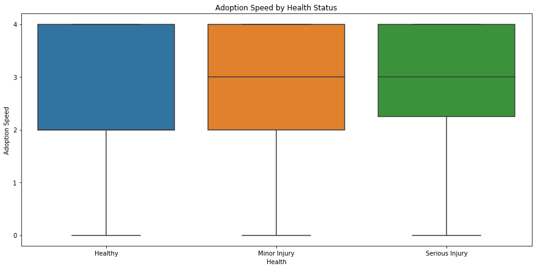

```python
plt.figure(figsize=(15, 7))
ax = sns.boxplot(x='Health', y='AdoptionSpeed', data=train)
plt.title('Adoption Speed by Health Status')
plt.xticks([0, 1, 2], ['Healthy', 'Minor Injury', 'Serious Injury'])
plt.ylabel('Adoption Speed')
plt.yticks([0, 1, 2, 3, 4])
plt.show()
```

### Quantity

Number of pets represented in profile

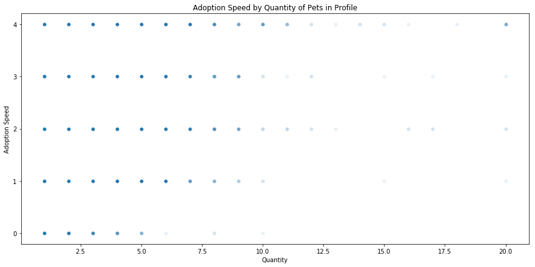

```python
plt.figure(figsize=(15, 7))
ax = sns.scatterplot(x='Quantity', y='AdoptionSpeed', data=train, alpha=0.1)
plt.title('Adoption Speed by Quantity of Pets in Profile')
plt.ylabel('Adoption Speed')
plt.yticks([0, 1, 2, 3, 4])
plt.show()
```

### Fee

Adoption fee (0 = Free)

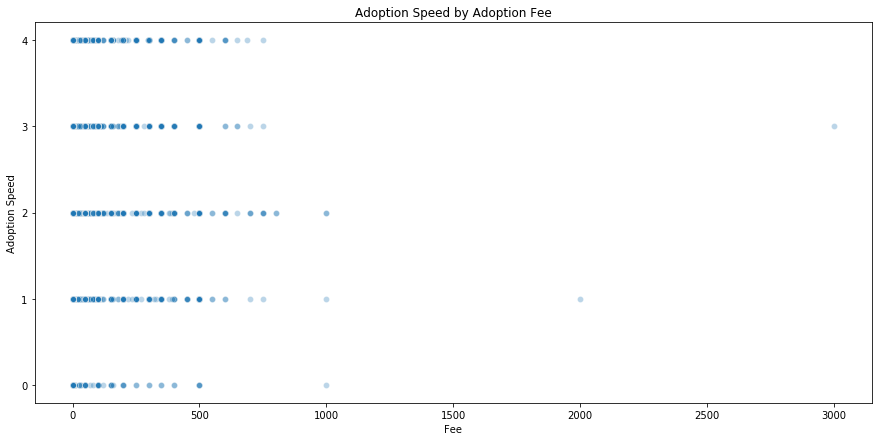

```python
plt.figure(figsize=(15, 7))
ax = sns.scatterplot(x='Fee', y='AdoptionSpeed', data=train, alpha=0.3)
plt.title('Adoption Speed by Adoption Fee')
plt.ylabel('Adoption Speed')
plt.yticks([0, 1, 2, 3, 4])
plt.show()
```

### State

State location in Malaysia (state names are in the StateLabels dictionary). An issue is there are different states in the train and test sets. I will create a variable based on the value counts in a state.

```python
train.State.value_counts().head()
```

```
41326    8714
41401    3845
41327     843
41336     507
41330     420
Name: State, dtype: int64
```

```python
state_dict = train.State.value_counts().to_dict()
train['State'] = train.State.map(state_dict)

state_dict = test.State.value_counts().to_dict()
test['State'] = test.State.map(state_dict)
```

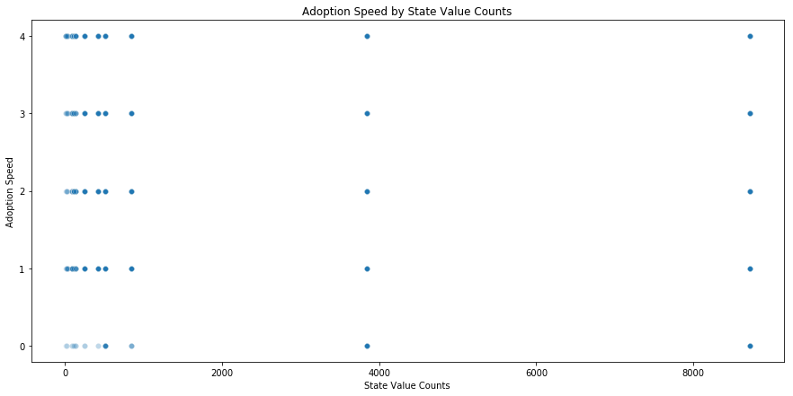

```python
plt.figure(figsize=(15, 7))
ax = sns.scatterplot(x='State', y='AdoptionSpeed', data=train, alpha=0.1)
plt.title('Adoption Speed by State Value Counts')
plt.xlabel('State Value Counts')
plt.ylabel('Adoption Speed')
plt.yticks([0, 1, 2, 3, 4])
plt.show()
```

### RescuerID

Unique hash ID of rescuer. Again, there are different rescuers in the train and test sets. I will create a variable based on rescuer value counts.

```python
train.RescuerID.value_counts().head()
```

```
fa90fa5b1ee11c86938398b60abc32cb    459
aa66486163b6cbc25ea62a34b11c9b91    315
c00756f2bdd8fa88fc9f07a8309f7d5d    231
b53c34474d9e24574bcec6a3d3306a0d    228
ee2747ce26468ec44c7194e7d1d9dad9    156
Name: RescuerID, dtype: int64
```

```python
rescuer_dict = train.RescuerID.value_counts().to_dict()
train.RescuerID = train.RescuerID.map(rescuer_dict)

rescuer_dict = test.RescuerID.value_counts().to_dict()
test.RescuerID = test.RescuerID.map(rescuer_dict)
```

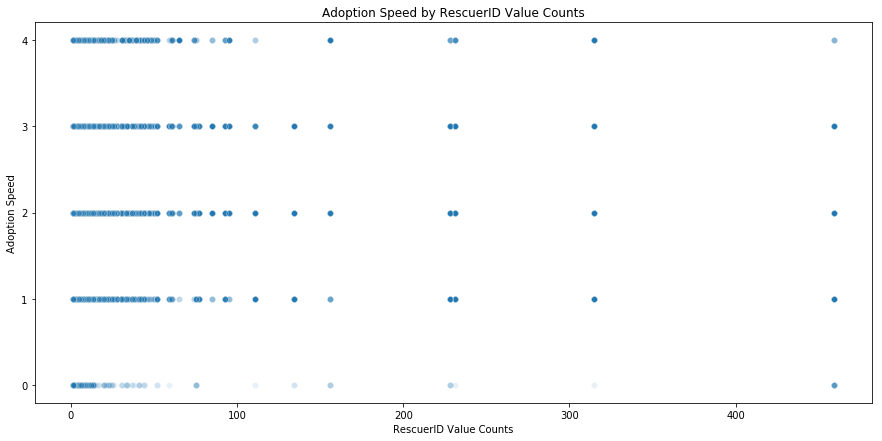

```python
plt.figure(figsize=(15, 7))
ax = sns.scatterplot(x='RescuerID', y='AdoptionSpeed', data=train, alpha=0.1)
plt.title('Adoption Speed by RescuerID Value Counts')
plt.xlabel('RescuerID Value Counts')
plt.ylabel('Adoption Speed')
plt.yticks([0, 1, 2, 3, 4])
plt.show()
```

### VideoAmt and PhotoAmt

Total uploaded videos and photos for this pet, respectively.

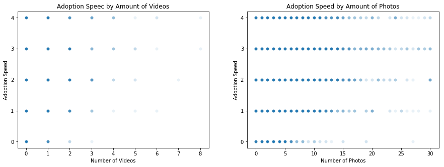

```python
plt.figure(figsize=(15, 5))
plt.subplot(1, 2, 1)
ax = sns.scatterplot(x='VideoAmt', y='AdoptionSpeed',  data=train, alpha=0.1)
plt.title('Adoption Speec by Amount of Videos')
plt.xlabel('Number of Videos')
plt.ylabel('Adoption Speed')
plt.yticks([0, 1, 2, 3, 4])
plt.subplot(1, 2, 2)
ax = sns.scatterplot(x='PhotoAmt', y='AdoptionSpeed', data=train, alpha=0.1)
plt.title('Adoption Speed by Amount of Photos')
plt.xlabel('Number of Photos')
plt.ylabel('Adoption Speed')
plt.yticks([0, 1, 2, 3, 4])
plt.show()
```

### Description

Profile write-up for this pet. The primary language used is English, with some in Malay or Chinese. In future I could include a custom sentiment analysis, but for now I will use the sentiment analysis provided.

Import sentiment analysis data:

```python
# I tooke the code to extract the sentiment and image analyses from:
# https://www.kaggle.com/abhishek/maybe-something-interesting-here
train_id = train['PetID']
test_id = test['PetID']

doc_sent_mag = []
doc_sent_score = []
nf_count = 0
for pet in train_id:
    try:

        with open('/Users/Joshua/Documents/Anaconda/PetFinderData/train_sentiment/' + pet + '.json', 'r') as f:
            sentiment = json.load(f)
        doc_sent_mag.append(sentiment['documentSentiment']['magnitude'])
        doc_sent_score.append(sentiment['documentSentiment']['score'])
    except FileNotFoundError:
        nf_count += 1
        doc_sent_mag.append(-1)
        doc_sent_score.append(-1)

train.loc[:, 'doc_sent_mag'] = doc_sent_mag
train.loc[:, 'doc_sent_score'] = doc_sent_score

doc_sent_mag = []
doc_sent_score = []
nf_count = 0
for pet in test_id:
    try:
        with open('/Users/Joshua/Documents/Anaconda/PetFinderData/test_sentiment/' + pet + '.json', 'r') as f:
            sentiment = json.load(f)
        doc_sent_mag.append(sentiment['documentSentiment']['magnitude'])
        doc_sent_score.append(sentiment['documentSentiment']['score'])
    except FileNotFoundError:
        nf_count += 1
        doc_sent_mag.append(-1)
        doc_sent_score.append(-1)

test.loc[:, 'doc_sent_mag'] = doc_sent_mag
test.loc[:, 'doc_sent_score'] = doc_sent_score
```

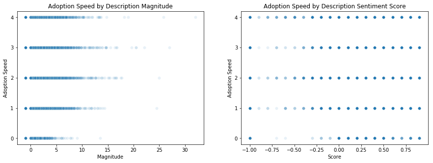

```python
plt.figure(figsize=(15, 5))
plt.subplot(1, 2, 1)
ax = sns.scatterplot(x='doc_sent_mag', y='AdoptionSpeed', data=train, alpha=0.1)
plt.title('Adoption Speed by Description Magnitude')
plt.xlabel('Magnitude')
plt.ylabel('Adoption Speed')
plt.yticks([0, 1, 2, 3, 4])
plt.subplot(1, 2, 2)
ax = sns.scatterplot(x='doc_sent_score', y='AdoptionSpeed', data=train, alpha=0.1)
plt.title('Adoption Speed by Description Sentiment Score')
plt.xlabel('Score')
plt.ylabel('Adoption Speed')
plt.yticks([0, 1, 2, 3, 4])
plt.show()
```

### Image Data

The competition hosts ran the images through Google's Vision API, providing analysis on Face Annotation, Label Annotation, Text Annotation and Image Properties. In future, I could do my own custom analysis of the images as well.

```python
vertex_xs = []
vertex_ys = []
bounding_confidences = []
bounding_importance_fracs = []
dominant_blues = []
dominant_greens = []
dominant_reds = []
dominant_pixel_fracs = []
dominant_scores = []
label_descriptions = []
label_scores = []
nf_count = 0
nl_count = 0
for pet in train_id:
    try:
        with open('/Users/Joshua/Documents/Anaconda/PetFinderData/train_metadata/' + pet + '-1.json', 'r') as f:
            data = json.load(f)
        vertex_x = data['cropHintsAnnotation']['cropHints'][0]['boundingPoly']['vertices'][2]['x']
        vertex_xs.append(vertex_x)
        vertex_y = data['cropHintsAnnotation']['cropHints'][0]['boundingPoly']['vertices'][2]['y']
        vertex_ys.append(vertex_y)
        bounding_confidence = data['cropHintsAnnotation']['cropHints'][0]['confidence']
        bounding_confidences.append(bounding_confidence)
        bounding_importance_frac = data['cropHintsAnnotation']['cropHints'][0].get('importanceFraction', -1)
        bounding_importance_fracs.append(bounding_importance_frac)
        dominant_blue = data['imagePropertiesAnnotation']['dominantColors']['colors'][0]['color']['blue']
        dominant_blues.append(dominant_blue)
        dominant_green = data['imagePropertiesAnnotation']['dominantColors']['colors'][0]['color']['green']
        dominant_greens.append(dominant_green)
        dominant_red = data['imagePropertiesAnnotation']['dominantColors']['colors'][0]['color']['red']
        dominant_reds.append(dominant_red)
        dominant_pixel_frac = data['imagePropertiesAnnotation']['dominantColors']['colors'][0]['pixelFraction']
        dominant_pixel_fracs.append(dominant_pixel_frac)
        dominant_score = data['imagePropertiesAnnotation']['dominantColors']['colors'][0]['score']
        dominant_scores.append(dominant_score)
        if data.get('labelAnnotations'):
            label_description = data['labelAnnotations'][0]['description']
            label_descriptions.append(label_description)
            label_score = data['labelAnnotations'][0]['score']
            label_scores.append(label_score)
        else:
            nl_count += 1
            label_descriptions.append('nothing')
            label_scores.append(-1)
    except FileNotFoundError:
        nf_count += 1
        vertex_xs.append(-1)
        vertex_ys.append(-1)
        bounding_confidences.append(-1)
        bounding_importance_fracs.append(-1)
        dominant_blues.append(-1)
        dominant_greens.append(-1)
        dominant_reds.append(-1)
        dominant_pixel_fracs.append(-1)
        dominant_scores.append(-1)
        label_descriptions.append('nothing')
        label_scores.append(-1)

print(nf_count)
print(nl_count)
train.loc[:, 'vertex_x'] = vertex_xs
train.loc[:, 'vertex_y'] = vertex_ys
train.loc[:, 'bounding_confidence'] = bounding_confidences
train.loc[:, 'bounding_importance'] = bounding_importance_fracs
train.loc[:, 'dominant_blue'] = dominant_blues
train.loc[:, 'dominant_green'] = dominant_greens
train.loc[:, 'dominant_red'] = dominant_reds
train.loc[:, 'dominant_pixel_frac'] = dominant_pixel_fracs
train.loc[:, 'dominant_score'] = dominant_scores
train.loc[:, 'label_description'] = label_descriptions
train.loc[:, 'label_score'] = label_scores


vertex_xs = []
vertex_ys = []
bounding_confidences = []
bounding_importance_fracs = []
dominant_blues = []
dominant_greens = []
dominant_reds = []
dominant_pixel_fracs = []
dominant_scores = []
label_descriptions = []
label_scores = []
nf_count = 0
nl_count = 0
for pet in test_id:
    try:
        with open('/Users/Joshua/Documents/Anaconda/PetFinderData/test_metadata/' + pet + '-1.json', 'r') as f:
            data = json.load(f)
        vertex_x = data['cropHintsAnnotation']['cropHints'][0]['boundingPoly']['vertices'][2]['x']
        vertex_xs.append(vertex_x)
        vertex_y = data['cropHintsAnnotation']['cropHints'][0]['boundingPoly']['vertices'][2]['y']
        vertex_ys.append(vertex_y)
        bounding_confidence = data['cropHintsAnnotation']['cropHints'][0]['confidence']
        bounding_confidences.append(bounding_confidence)
        bounding_importance_frac = data['cropHintsAnnotation']['cropHints'][0].get('importanceFraction', -1)
        bounding_importance_fracs.append(bounding_importance_frac)
        dominant_blue = data['imagePropertiesAnnotation']['dominantColors']['colors'][0]['color']['blue']
        dominant_blues.append(dominant_blue)
        dominant_green = data['imagePropertiesAnnotation']['dominantColors']['colors'][0]['color']['green']
        dominant_greens.append(dominant_green)
        dominant_red = data['imagePropertiesAnnotation']['dominantColors']['colors'][0]['color']['red']
        dominant_reds.append(dominant_red)
        dominant_pixel_frac = data['imagePropertiesAnnotation']['dominantColors']['colors'][0]['pixelFraction']
        dominant_pixel_fracs.append(dominant_pixel_frac)
        dominant_score = data['imagePropertiesAnnotation']['dominantColors']['colors'][0]['score']
        dominant_scores.append(dominant_score)
        if data.get('labelAnnotations'):
            label_description = data['labelAnnotations'][0]['description']
            label_descriptions.append(label_description)
            label_score = data['labelAnnotations'][0]['score']
            label_scores.append(label_score)
        else:
            nl_count += 1
            label_descriptions.append('nothing')
            label_scores.append(-1)
    except FileNotFoundError:
        nf_count += 1
        vertex_xs.append(-1)
        vertex_ys.append(-1)
        bounding_confidences.append(-1)
        bounding_importance_fracs.append(-1)
        dominant_blues.append(-1)
        dominant_greens.append(-1)
        dominant_reds.append(-1)
        dominant_pixel_fracs.append(-1)
        dominant_scores.append(-1)
        label_descriptions.append('nothing')
        label_scores.append(-1)

#print(nf_count)
test.loc[:, 'vertex_x'] = vertex_xs
test.loc[:, 'vertex_y'] = vertex_ys
test.loc[:, 'bounding_confidence'] = bounding_confidences
test.loc[:, 'bounding_importance'] = bounding_importance_fracs
test.loc[:, 'dominant_blue'] = dominant_blues
test.loc[:, 'dominant_green'] = dominant_greens
test.loc[:, 'dominant_red'] = dominant_reds
test.loc[:, 'dominant_pixel_frac'] = dominant_pixel_fracs
test.loc[:, 'dominant_score'] = dominant_scores
test.loc[:, 'label_description'] = label_descriptions
test.loc[:, 'label_score'] = label_scores
```

```
341
2
```

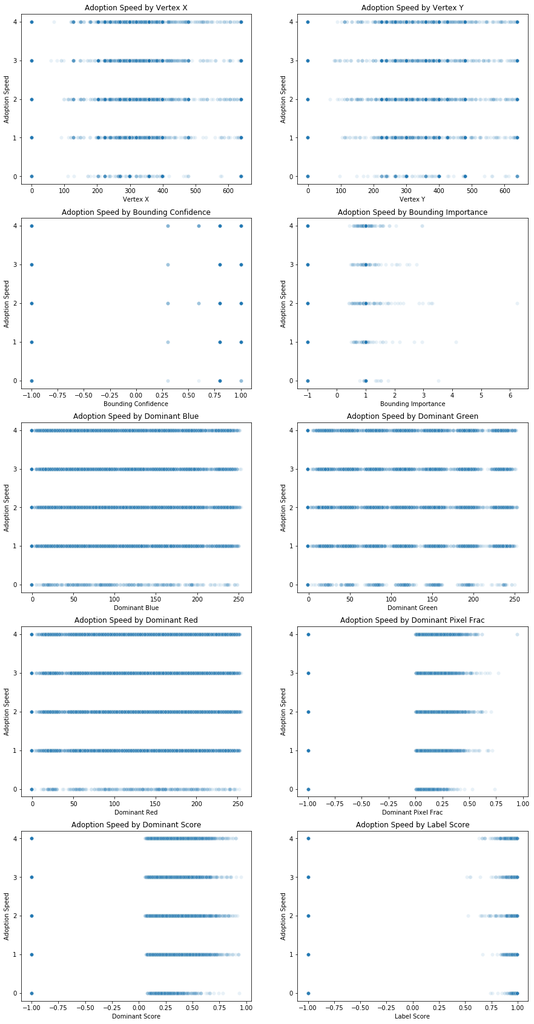

```python
plt.figure(figsize=(15, 30))
plt.subplot(5, 2, 1)
ax = sns.scatterplot(x='vertex_x', y='AdoptionSpeed', data=train, alpha=0.1)
plt.title('Adoption Speed by Vertex X')
plt.ylabel('Adoption Speed')
plt.yticks([0, 1, 2, 3, 4])
plt.xlabel('Vertex X')
plt.subplot(5, 2, 2)
ax = sns.scatterplot(x='vertex_y', y='AdoptionSpeed', data=train, alpha=0.1)
plt.ylabel('Adoption Speed')
plt.yticks([0, 1, 2, 3, 4])
plt.xlabel('Vertex Y')
plt.title('Adoption Speed by Vertex Y')
plt.subplot(5, 2, 3)
ax = sns.scatterplot(x='bounding_confidence', y='AdoptionSpeed', data=train, alpha=0.1)
plt.title('Adoption Speed by Bounding Confidence')
plt.ylabel('Adoption Speed')
plt.yticks([0, 1, 2, 3, 4])
plt.xlabel('Bounding Confidence')
plt.subplot(5, 2, 4)
ax = sns.scatterplot(x='bounding_importance', y='AdoptionSpeed', data=train, alpha=0.1)
plt.title('Adoption Speed by Bounding Importance')
plt.ylabel('Adoption Speed')
plt.yticks([0, 1, 2, 3, 4])
plt.xlabel('Bounding Importance')
plt.subplot(5, 2, 5)
ax = sns.scatterplot(x='dominant_blue', y='AdoptionSpeed', data=train, alpha=0.1)
plt.title('Adoption Speed by Dominant Blue')
plt.ylabel('Adoption Speed')
plt.yticks([0, 1, 2, 3, 4])
plt.xlabel('Dominant Blue')
plt.subplot(5, 2, 6)
ax = sns.scatterplot(x='dominant_green', y='AdoptionSpeed', data=train, alpha=0.1)
plt.title('Adoption Speed by Dominant Green')
plt.ylabel('Adoption Speed')
plt.yticks([0, 1, 2, 3, 4])
plt.xlabel('Dominant Green')
plt.subplot(5, 2, 7)
ax = sns.scatterplot(x='dominant_red', y='AdoptionSpeed', data=train, alpha=0.1)
plt.title('Adoption Speed by Dominant Red')
plt.ylabel('Adoption Speed')
plt.yticks([0, 1, 2, 3, 4])
plt.xlabel('Dominant Red')
plt.subplot(5, 2, 8)
ax = sns.scatterplot(x='dominant_pixel_frac', y='AdoptionSpeed', data=train, alpha=0.1)
plt.title('Adoption Speed by Dominant Pixel Frac')
plt.ylabel('Adoption Speed')
plt.yticks([0, 1, 2, 3, 4])
plt.xlabel('Dominant Pixel Frac')
plt.subplot(5, 2, 9)
ax = sns.scatterplot(x='dominant_score', y='AdoptionSpeed', data=train, alpha=0.1)
plt.title('Adoption Speed by Dominant Score')
plt.ylabel('Adoption Speed')
plt.yticks([0, 1, 2, 3, 4])
plt.xlabel('Dominant Score')
plt.subplot(5, 2, 10)
ax = sns.scatterplot(x='label_score', y='AdoptionSpeed', data=train, alpha=0.1)
plt.title('Adoption Speed by Label Score')
plt.ylabel('Adoption Speed')
plt.yticks([0, 1, 2, 3, 4])
plt.xlabel('Label Score')
plt.show()
```

## Modelling

The competition is judged using the quadratic weighted kappa metric, so I used a linear regression XGBoost model to model the data, and then chose the cutpoints that maximized the quadratic weighted kappa.

### Data Preparation and Evaluation Metric

```python
X = train.drop('AdoptionSpeed', axis=1)
y = train['AdoptionSpeed']

categorical_variables = ['Gender', 'Color1', 'Color2', 'Color3', 'Vaccinated', 'Dewormed', 'Sterilized',
                         'PureBred', 'NoName']
numeric_variables = ['Breed1', 'Breed2', 'FurLength', 'MaturitySize', 'State', 'RescuerID', 'Name',  'Age',
                     'Quantity', 'Health', 'Fee', 'VideoAmt', 'PhotoAmt', 'doc_sent_mag', 'doc_sent_score',
                     'vertex_x', 'vertex_y', 'bounding_confidence', 'bounding_importance', 'dominant_blue',
                     'dominant_green', 'dominant_red', 'dominant_pixel_frac', 'dominant_score', 'label_score']

X_categorical = pd.DataFrame(X, columns=categorical_variables)
test_categorical = pd.DataFrame(test, columns=categorical_variables)
X_categorical_dummies = pd.get_dummies(X_categorical, columns=categorical_variables, drop_first=True)
test_categorical_dummies = pd.get_dummies(test_categorical, columns=categorical_variables, drop_first=True)

X_numeric = pd.DataFrame(X, columns=numeric_variables)
test_numeric = pd.DataFrame(test, columns=numeric_variables)
scaler = StandardScaler()
scaler.fit(X_numeric.values)
X_scaled = scaler.transform(X_numeric.values)
test_scaled = scaler.transform(test_numeric.values)
X_scaled_df = pd.DataFrame(X_scaled, index=X_numeric.index, columns=X_numeric.columns)
test_scaled_df = pd.DataFrame(test_scaled, index=test_numeric.index, columns=test_numeric.columns)

X = pd.concat([X_categorical_dummies, X_numeric], axis=1)
test = pd.concat([test_categorical_dummies, test_numeric], axis=1)

X_train, X_test, y_train, y_test = train_test_split(X, y, test_size=0.2, random_state=42)
```

[output not shown]

```python
# The following 3 functions were taken from Ben Hamner's github repository: https://github.com/benhamner/Metrics
def confusion_matrix(rater_a, rater_b, min_rating=None, max_rating=None):
    """
    Returns the confusion matrix between rater's ratings
    """
    assert(len(rater_a) == len(rater_b))
    if min_rating is None:
        min_rating = min(rater_a + rater_b)
    if max_rating is None:
        max_rating = max(rater_a + rater_b)
    num_ratings = int(max_rating - min_rating + 1)
    conf_mat = [[0 for i in range(num_ratings)]
                for j in range(num_ratings)]
    for a, b in zip(rater_a, rater_b):
        conf_mat[a - min_rating][b - min_rating] += 1
    return conf_mat


def histogram(ratings, min_rating=None, max_rating=None):
    """
    Returns the counts of each type of rating that a rater made
    """
    if min_rating is None:
        min_rating = min(ratings)
    if max_rating is None:
        max_rating = max(ratings)
    num_ratings = int(max_rating - min_rating + 1)
    hist_ratings = [0 for x in range(num_ratings)]
    for r in ratings:
        hist_ratings[r - min_rating] += 1
    return hist_ratings

def quadratic_weighted_kappa(y, y_pred):
    """
    Calculates the quadratic weighted kappa
    axquadratic_weighted_kappa calculates the quadratic weighted kappa
    value, which is a measure of inter-rater agreement between two raters
    that provide discrete numeric ratings.  Potential values range from -1
    (representing complete disagreement) to 1 (representing complete
    agreement).  A kappa value of 0 is expected if all agreement is due to
    chance.
    quadratic_weighted_kappa(rater_a, rater_b), where rater_a and rater_b
    each correspond to a list of integer ratings.  These lists must have the
    same length.
    The ratings should be integers, and it is assumed that they contain
    the complete range of possible ratings.
    quadratic_weighted_kappa(X, min_rating, max_rating), where min_rating
    is the minimum possible rating, and max_rating is the maximum possible
    rating
    """
    rater_a = y
    rater_b = y_pred
    min_rating=None
    max_rating=None
    rater_a = np.array(rater_a, dtype=int)
    rater_b = np.array(rater_b, dtype=int)
    assert(len(rater_a) == len(rater_b))
    if min_rating is None:
        min_rating = min(min(rater_a), min(rater_b))
    if max_rating is None:
        max_rating = max(max(rater_a), max(rater_b))
    conf_mat = confusion_matrix(rater_a, rater_b,
                                min_rating, max_rating)
    num_ratings = len(conf_mat)
    num_scored_items = float(len(rater_a))

    hist_rater_a = histogram(rater_a, min_rating, max_rating)
    hist_rater_b = histogram(rater_b, min_rating, max_rating)

    numerator = 0.0
    denominator = 0.0

    for i in range(num_ratings):
        for j in range(num_ratings):
            expected_count = (hist_rater_a[i] * hist_rater_b[j]
                              / num_scored_items)
            d = pow(i - j, 2.0) / pow(num_ratings - 1, 2.0)
            numerator += d * conf_mat[i][j] / num_scored_items
            denominator += d * expected_count / num_scored_items

    return (1.0 - numerator / denominator)
```

```python
# This function finds the cutoffs that maximize quatratic kappa
# it was taken from https://www.kaggle.com/c/petfinder-adoption-prediction/discussion/76107
class OptimizedRounder(object):
    def __init__(self):
        self.coef_ = 0

    def _kappa_loss(self, coef, X, y):
        X_p = np.copy(X)
        for i, pred in enumerate(X_p):
            if pred < coef[0]:
                X_p[i] = 0
            elif pred >= coef[0] and pred < coef[1]:
                X_p[i] = 1
            elif pred >= coef[1] and pred < coef[2]:
                X_p[i] = 2
            elif pred >= coef[2] and pred < coef[3]:
                X_p[i] = 3
            else:
                X_p[i] = 4

        ll = quadratic_weighted_kappa(y, X_p)
        return -ll

    def fit(self, X, y):
        loss_partial = partial(self._kappa_loss, X=X, y=y)
        initial_coef = [0.5, 1.5, 2.5, 3.5]
        self.coef_ = sp.optimize.minimize(loss_partial, initial_coef, method='nelder-mead')

    def predict(self, X, coef):
        X_p = np.copy(X)
        for i, pred in enumerate(X_p):
            if pred < coef[0]:
                X_p[i] = 0
            elif pred >= coef[0] and pred < coef[1]:
                X_p[i] = 1
            elif pred >= coef[1] and pred < coef[2]:
                X_p[i] = 2
            elif pred >= coef[2] and pred < coef[3]:
                X_p[i] = 3
            else:
                X_p[i] = 4
        return X_p

    def coefficients(self):
        return self.coef_['x']
```

### XGB regression model

```python
%%capture
params = {
    'max_depth': 6,
    'min_child_weight': 1,
    'eta': 0.3,
    'subsample': 0.7,
    'colsample_bytree': 0.7,
    'objective':'reg:linear',
    'eval_metric' : 'rmse'
}

base_model = xgb.train(
    params,
    dtrain,
    num_boost_round=999,
    evals=[(dtest, 'Test')],
    early_stopping_rounds=10
)
```

```python
preds_base = base_model.predict(dtest).astype(float)
optR_base = OptimizedRounder()
optR_base.fit(preds_base, y_test)
coef_base = optR_base.coefficients()
cuts_base = optR_base.predict(preds_base, coef_base).astype(int)
print('Base model quadratic weighted kappa = {}'.format(quadratic_weighted_kappa(cuts_base, y_test)))
```

```
Base model quadratic weighted kappa = 0.41360010320043217
```

Tune max_depth and min_child_weight

```python
%%capture
gridsearch_params = [(max_depth, min_child_weight) for max_depth in range(2, 5) for min_child_weight in range(5,8)]
#Define initial best params and RMSE
min_rmse = float("Inf")
best_params = None
for max_depth, min_child_weight in gridsearch_params:
    # Update parameters
    params['max_depth'] = max_depth
    params['min_child_weight'] = min_child_weight
    # Run CV
    cv_results = xgb.cv(
        params,
        dtrain,
        num_boost_round=500,
        nfold=5,
        metrics={'rmse'},
        early_stopping_rounds=10,
        verbose_eval=None,
        seed=42
    )
# Update best RMSE
mean_rmse = cv_results['test-rmse-mean'].min()
boost_rounds = cv_results['test-rmse-mean'].argmin()
if mean_rmse < min_rmse:
    min_rmse = mean_rmse
    best_params = (max_depth,min_child_weight)
```

```python
print("Best params: {}, {}, RMSE: {}".format(best_params[0], best_params[1], min_rmse))
```

```
Best params: 4, 7, RMSE: 1.0710520000000001
```

```python
%%capture
params = {
    'max_depth': 4,
    'min_child_weight': 7,
    'eta': 0.05,
    'subsample': 0.7,
    'colsample_bytree': 0.7,
    'gamma': 5,
    'objective': 'reg:linear',
    'metrics': 'rmse'}

tuned_model = xgb.train(
    params,
    dtrain,
    num_boost_round=999,
    evals=[(dtest, 'Test')],
    early_stopping_rounds=10
)
```

```python
preds_tuned = tuned_model.predict(dtest).astype(float)
optR_tuned = OptimizedRounder()
optR_tuned.fit(preds_tuned, y_test)
coef_tuned = optR_tuned.coefficients()
cuts_tuned = optR_tuned.predict(preds_tuned, coef_tuned).astype(int)
print('Tuned model quadratic weighted kappa = {}'.format(quadratic_weighted_kappa(cuts_tuned, y_test)))
```

```
Tuned model quadratic weighted kappa = 0.43713294430708094
```

```python
# make submission
preds_submit = tuned_model.predict(dtest_submission).astype(float)
cuts_submit = optR_tuned.predict(preds_submit, coef_tuned).astype(int)
submission = pd.DataFrame({'PetID': test_id, 'AdoptionSpeed': cuts_submit})
submission.to_csv('submission.csv', index=False)
```

This model placed 104th position on the leaderboard at the time of submission.

### Interpreting the Model

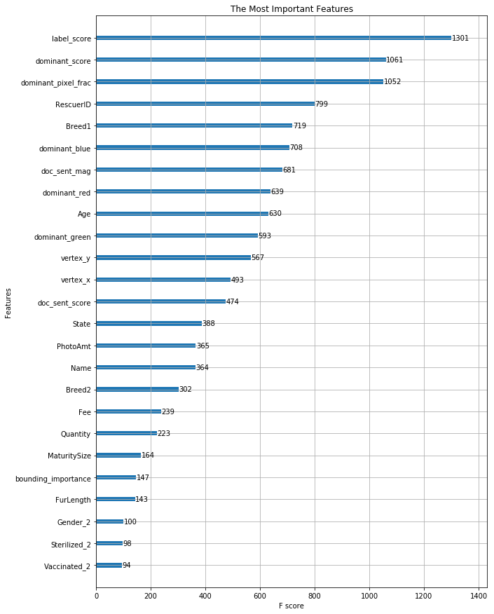

```python
fig, ax = plt.subplots(figsize=(10,15))
xgb.plot_importance(final_model, ax=ax, max_num_features=25, title='The Most Important Features')
plt.show()
```

Label score, dominant score, and dominant pixel frac from the image analysis were the most important features in the model. This makes sense, since the photos of the pet are probably one of the most important things that influence people when considering whether to adopt a pet.

## Conclusion

I could further enhance the model with custom natural language and image analysis, potentially stacking multiple models, although there is a computational time limit for this competition.

The model could be implemented as a tool to help animal shelters and rescuers improve the appeal of pet profiles, improving pet adoption performance and reducing animal suffering and euthanization around the world.